# Simulation Project

STAT 420, Summer 2018, Hussein Elmessilhy, hae2

## Simulation Study 1, Significance of Regression

**(a)** Introduction

In this study, I am trying to prove that the significance of regression test is a good indicator of whether the regression model is relevant or not to the data in hand.

To do so, data will be simulated from two different true models, one of them their output is function of all the predictors, while the other one their output is not a function of the predictors. To make sure of the variability of data to test with, each true model will be used with different values of error variance to generate the data as well as many simulations.

$$Y_i = \beta_0 + \beta_1 x_{i1} + \beta_2 x_{i2} + \beta_3 x_{i3} + \epsilon_i.$$

**(b)** Methods

```r
birthday = 19850322
set.seed(birthday)
setwd(".\\")
study1_data <- read.csv("study_1.csv", header = TRUE, sep = ",")

generate_data = function(data, sigma, params){

  y <- (as.matrix(cbind(rep(1, nrow(data)), data[,-1])) %*% as.matrix(params))
  y <- y + rnorm(nrow(data) , 0, sigma)
  return (cbind(y, data[,-1]))

}

simulate_model = function(data, simulations, sigma, params){

  fStats <- rep(0, simulations)
  pVal <- rep(0, simulations)
  rSquared <- rep(0, simulations)
  betas <- matrix(0, nrow = simulations, ncol = length(params))
  se <- rep(0, simulations)
  rmse <- rep(0, simulations)

  for (i in 1:simulations)
  {
    data <- generate_data(data, sigma, params)
    model <- lm(y ~ ., data)
    model_summary <- summary(model)
    betas[i,] <- coef(model)
    rSquared[i] <- model_summary$r.squared
    fStats[i] <- model_summary$fstatistic[1]
    pVal[i] <- 1 - pf(model_summary$fstatistic[1], model_summary$fstatistic[2], model_summary$fstatistic[3])
    se[i] <- model_summary$sigma
    rmse[i] <- sqrt(sum((data$y - model$fitted.values) ^ 2)/nrow(data))
  }

  result <- list()
  result$fStats <- fStats
  result$pVal <- pVal
  result$rSquared <- rSquared
  result$betas <- betas
  result$se <- se

  return (result)
}

study1_significant_1 <- simulate_model(study1_data, 2500, 1, c(3,1,1,1))
study1_significant_5 <- simulate_model(study1_data, 2500, 5, c(3,1,1,1))
study1_significant_10 <- simulate_model(study1_data, 2500, 10, c(3,1,1,1))

study1_nonSignificant_1 <- simulate_model(study1_data, 2500, 1, c(3,0,0,0))
study1_nonSignificant_5 <- simulate_model(study1_data, 2500, 5, c(3,0,0,0))
study1_nonSignificant_10 <- simulate_model(study1_data, 2500, 10, c(3,0,0,0))
```

**(c)** Results

Our regression models significance tests was able to conclude a right decision (model is significant by rejecting the null hypotheses) in each of the significant models simulations per sigma equal to the following (based on alpha value equal to 0.05):

- When sigma = 1 : 1
- When sigma = 5 : 0.3436
- When sigma = 10 : 0.1044

On the other hand, the regression models in the non-signofocant models were able to conclude a right decision (fail to reject the null hypotheses) in each of the non-significant models simulations per sigma equal to the following (based on alpha value equal to 0.05):

- When sigma = 1 : 0.9456
- When sigma = 5 : 0.95
- When sigma = 10 : 0.9448

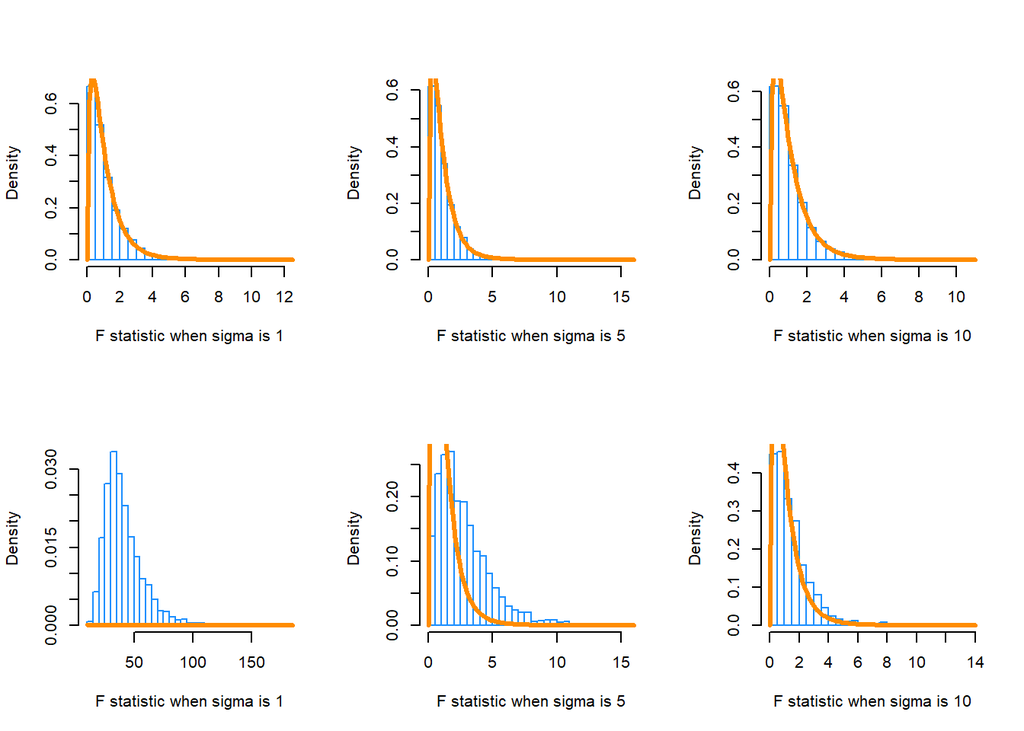

```r
# Plotting charts for the f statistic

# charts when the model is not significant
par(mfrow=c(2,3))

hist(study1_nonSignificant_1$fStats, prob = TRUE, breaks = 25,
     xlab = "F statistic when sigma is 1", main = "", border = "dodgerblue")
x <- seq(0, 100, length = 25)
curve(df(x, df1 = 3, df2 = nrow(study1_data) - 4  ),
 col = "darkorange", add = TRUE, lwd = 3)


hist(study1_nonSignificant_5$fStats, prob = TRUE, breaks = 25,
     xlab = "F statistic when sigma is 5", main = "", border = "dodgerblue")
x <- seq(0, 10, length = 25)
curve(df(x, df1 = 3, df2 = nrow(study1_data) - 4  ),
 col = "darkorange", add = TRUE, lwd = 3)

hist(study1_nonSignificant_10$fStats, prob = TRUE, breaks = 25,
     xlab = "F statistic when sigma is 10", main = "", border = "dodgerblue")
x <- seq(0, 10, length = 25)
curve(df(x, df1 = 3, df2 = nrow(study1_data) - 4  ),
 col = "darkorange", add = TRUE, lwd = 3)


#charts when the model is significant

hist(study1_significant_1$fStats, prob = TRUE, breaks = 25,
     xlab = "F statistic when sigma is 1", main = "", border = "dodgerblue")
x <- seq(0, 10, length = 25)
curve(df(x, df1 = 3, df2 = nrow(study1_data) - 4  ),
 col = "darkorange", add = TRUE, lwd = 3)


hist(study1_significant_5$fStats, prob = TRUE, breaks = 25,
     xlab = "F statistic when sigma is 5", main = "", border = "dodgerblue")
x <- seq(0, 10, length = 25)
curve(df(x, df1 = 3, df2 = nrow(study1_data) - 4  ),
 col = "darkorange", add = TRUE, lwd = 3)

hist(study1_significant_10$fStats, prob = TRUE, breaks = 25,
     xlab = "F statistic when sigma is 10", main = "", border = "dodgerblue")
x <- seq(0, 10, length = 25)
curve(df(x, df1 = 3, df2 = nrow(study1_data) - 4  ),
 col = "darkorange", add = TRUE, lwd = 3)
```

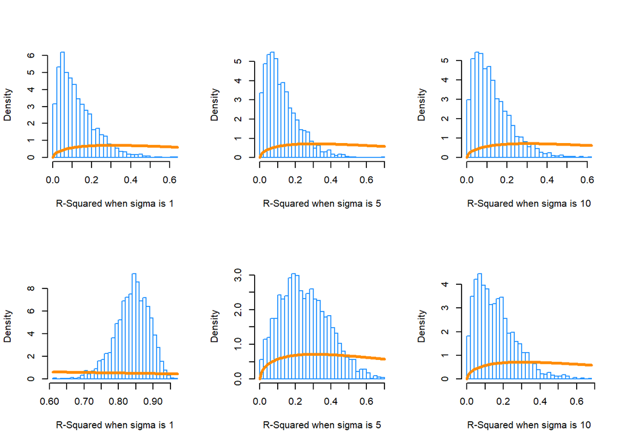

```r
# Plotting charts for the R-Squared

# charts when the model is not significant
par(mfrow=c(2,3))

hist(study1_nonSignificant_1$rSquared, prob = TRUE, breaks = 25,
     xlab = "R-Squared when sigma is 1", main = "", border = "dodgerblue")
x <- seq(0, 10, length = 25)
curve(df(x, df1 = 3, df2 = nrow(study1_data) - 4  ),
 col = "darkorange", add = TRUE, lwd = 3)


hist(study1_nonSignificant_5$rSquared, prob = TRUE, breaks = 25,
     xlab = "R-Squared when sigma is 5", main = "", border = "dodgerblue")
x <- seq(0, 10, length = 25)
curve(df(x, df1 = 3, df2 = nrow(study1_data) - 4  ),
 col = "darkorange", add = TRUE, lwd = 3)

hist(study1_nonSignificant_10$rSquared, prob = TRUE, breaks = 25,
     xlab = "R-Squared when sigma is 10", main = "", border = "dodgerblue")
x <- seq(0, 10, length = 25)
curve(df(x, df1 = 3, df2 = nrow(study1_data) - 4  ),
 col = "darkorange", add = TRUE, lwd = 3)


#charts when the model is significant

hist(study1_significant_1$rSquared, prob = TRUE, breaks = 25,
     xlab = "R-Squared when sigma is 1", main = "", border = "dodgerblue")
x <- seq(0, 10, length = 25)
curve(df(x, df1 = 3, df2 = nrow(study1_data) - 4  ),
 col = "darkorange", add = TRUE, lwd = 3)


hist(study1_significant_5$rSquared, prob = TRUE, breaks = 25,
     xlab = "R-Squared when sigma is 5", main = "", border = "dodgerblue")
x <- seq(0, 10, length = 25)
curve(df(x, df1 = 3, df2 = nrow(study1_data) - 4  ),
 col = "darkorange", add = TRUE, lwd = 3)

hist(study1_significant_10$rSquared, prob = TRUE, breaks = 25,
     xlab = "R-Squared when sigma is 10", main = "", border = "dodgerblue")
x <- seq(0, 10, length = 25)
curve(df(x, df1 = 3, df2 = nrow(study1_data) - 4  ),
 col = "darkorange", add = TRUE, lwd = 3)
```

## Simulation Study 2, Using RMSE for Selection?

**(a)** Introduction

**(b)** Methods

```r
setwd(".\\")
study2_data <- read.csv("study_2.csv", header = TRUE, sep = ",")

generate_data = function(data, sigma, params){

  y <- (as.matrix(cbind(rep(1, nrow(data)), data[,-1])) %*% as.matrix(params))
  y <- y + rnorm(nrow(data) , 0, sigma)
  return (cbind(y, data[,-1]))

}

simulate_model = function(data, simulations, sigma, params, predictors_number, test_count){

  best_model_train <- rep(0, simulations)
  best_model_test <- rep(0, simulations)
  rSquared_total <- rep(0, predictors_number)
  rmse_train_total <- rep(0, predictors_number)
  rmse_test_total <- rep(0, predictors_number)

  for (simulation_counter in 1:simulations)
  {
    data <- generate_data(data, sigma, params)
    tst_idx = sample(1:nrow(data), test_count)
    train_data <- data[-tst_idx,]
    test_data <- data[tst_idx,]

    current_best_train_rmse <- Inf
    current_best_test_rmse <- Inf
    current_best_train_rmse_index <- 0
    current_best_test_rmse_index <- 0

    for(predictors_counter in 1:predictors_number)
    {
      # create a dynamic formula based on the number of predictors
      xnam <- paste0("x", 1:predictors_counter)
      fmla <- as.formula(paste("y ~ ", paste(xnam, collapse= "+")))
      model <- lm(fmla, train_data)
      model_summary <- summary(model)
      rSquared_total[predictors_counter] <- rSquared_total[predictors_counter] + model_summary$r.squared

      # updating total RMSE train and test
      rmse_train <- sqrt(sum((train_data$y - model$fitted.values) ^ 2)/nrow(train_data))
      rmse_train_total[predictors_counter] <- rmse_train_total[predictors_counter] + rmse_train

      fitted_test <- predict(model, test_data[,-1])
      rmse_test <- sqrt(sum((test_data[,1] - fitted_test) ^ 2)/nrow(test_data))
       rmse_test_total[predictors_counter] <- rmse_test_total[predictors_counter] + rmse_test

       # update current best model based on train and test RMSE for this simulation
       if(rmse_train < current_best_train_rmse)
       {
         current_best_train_rmse <- rmse_train
         current_best_train_rmse_index <- predictors_counter
       }

       if(rmse_test < current_best_test_rmse)
       {
         current_best_test_rmse <- rmse_test
         current_best_test_rmse_index <- predictors_counter
       }
    }

    #update index of best model for this simulation
    best_model_train[simulation_counter] <- current_best_train_rmse_index
    best_model_test[simulation_counter] <- current_best_test_rmse_index

  }

  result <- list()
  result$best_model_train <- best_model_train
  result$best_model_test <- best_model_test
  result$rSquared_mean <- rSquared_total / simulations
  result$rmse_train_mean <- rmse_train_total / simulations
  result$rmse_test_mean <- rmse_test_total / simulations

  return (result)
}



study2_sigma1_models <- simulate_model(data = study2_data, simulations = 1000, sigma = 1, params = c(0, 5, -4, 1.6, -1.1, 0.7, 0.3, 0, 0, 0),  predictors_number = 9, test_count = 250)

study2_sigma2_models <- simulate_model(data = study2_data, simulations = 1000, sigma = 2, params = c(0, 5, -4, 1.6, -1.1, 0.7, 0.3, 0, 0, 0),  predictors_number = 9, test_count = 250)

study2_sigma4_models <- simulate_model(data = study2_data, simulations = 1000, sigma = 4, params = c(0, 5, -4, 1.6, -1.1, 0.7, 0.3, 0, 0, 0),  predictors_number = 9, test_count = 250)
```

**(c)** Results

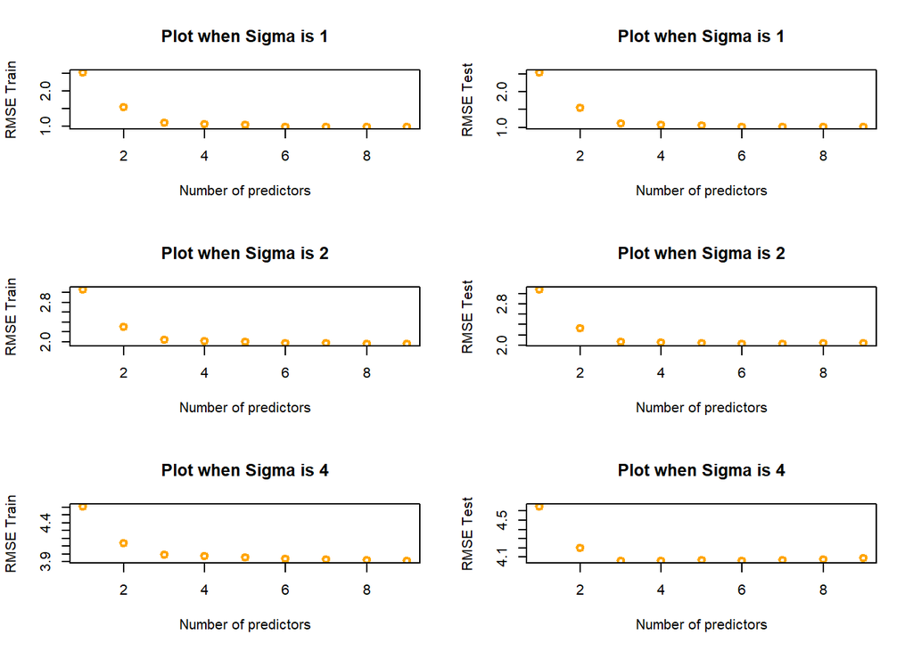

```r
#x11(width=9, height=20, pointsize=12)
par(mfrow=c(3,2))

plot(study2_sigma1_models$rmse_train_mean, xlab = 'Number of predictors', ylab = 'RMSE Train', lwd = 2, col = 'orange', main = 'Plot when Sigma is 1')

plot(study2_sigma1_models$rmse_test_mean, xlab = 'Number of predictors', ylab = 'RMSE Test', lwd = 2, col = 'orange', main = 'Plot when Sigma is 1')


plot(study2_sigma2_models$rmse_train_mean, xlab = 'Number of predictors', ylab = 'RMSE Train', lwd = 2, col = 'orange', main = 'Plot when Sigma is 2')

plot(study2_sigma2_models$rmse_test_mean, xlab = 'Number of predictors', ylab = 'RMSE Test', lwd = 2, col = 'orange', main = 'Plot when Sigma is 2')


plot(study2_sigma4_models$rmse_train_mean, xlab = 'Number of predictors', ylab = 'RMSE Train', lwd = 2, col = 'orange', main = 'Plot when Sigma is 4')

plot(study2_sigma4_models$rmse_test_mean, xlab = 'Number of predictors', ylab = 'RMSE Test', lwd = 2, col = 'orange', main = 'Plot when Sigma is 4')
```